# Simulación virtual de contagio adaptada al COVID-19

Este estudio tiene la finalidad de presentar los resultados de una simulación virtual sobre un modelo de contagio adaptada al COVID-19. Se han simulado varios escenarios:

- En el primero de ellos muestra una situación normal, sin medidas de prevención.
- En el segundo se intenta reflejar una situación con reducción en la libre circulación de personas y por lo tanto las exposiciones con los individuos de su entorno.
- En el tercer escenario se simula el uso de mascarilla, disminuyendo la posibilidad de contagio entre los individuos.
- En el último escenario vamos a simular una vacunación del 40% de la población, aumentando el porcentaje inmunes hasta el 60%.

Descripción del **algoritmo** y parámetros utilizados:

```python
import random
import pandas as pd
import numpy as np
import matplotlib.pyplot as plt
import seaborn as sns
```

### Genera los individuos de la población

```python
# Genera un listado de personas
# En función de la variable prob_inmune esta población será más o menos resistente al virus.

def generaPoblacion():

    poblacion = []

    for i in range (tam_poblacion):

        #Aqui definimos si el individuo de la población es inmune
        if random.random() <= prob_inmune:
            estado = 1 #Inmune
        else:
            estado = 0 #Susceptible de contagio

        persona = {"Id": i,
                   "Estado": estado,
                   "Dias_Contagiado": -1,
                   #"Dia_Contagio":-1,
                   #"Usuario_Contagia": -1
                  }

        poblacion.append(persona)

    return poblacion
```

### Genera las relaciones entre la población

```python
#Relaciones entre las personas
def generaRelaciones():

    relaciones = []

    for i in range (tam_poblacion):
        relacion = []
        #Cada persona se relaciona con otras un número aleatorio de veces
        num_relaciones = random.randint(num_relaciones_min, num_relaciones_max)

        for j in range(num_relaciones):
            index = random.randint(0, tam_poblacion-1)

            #Control para no relacionar consigo mismo
            while index == i:
                index = random.randint(0, tam_poblacion-1)
            relacion.append(index)

        relaciones.append(relacion)

    return relaciones
```

### Infectamos individuos al azar

```python
def inicializaContagios(poblacion):
    for i in range(num_infectados_init):
        poblacion[random.randint(0, tam_poblacion-1)]['Estado'] = 2

    return poblacion
```

### Simulación

```python
def simulacion(poblacion, relaciones):
    resultados = []

    for dia in range(num_iteraciones):

        positivos = 0
        negativos = 0
        curados = 0
        fallecidos = 0

        for i in range(tam_poblacion):

            #Negativo
            if poblacion[i]['Estado'] == 0 or poblacion[i]['Estado'] == 1:
                negativos  += 1

            #Positivo
            elif poblacion[i]['Estado'] == 2:
                positivos += 1
                poblacion[i]['Dias_Contagiado'] += 1

                #Incubación
                if poblacion[i]['Dias_Contagiado'] >= num_dias_incubacion:

                    #Las presonas relacionadas
                    for relacion in relaciones[i]:
                        #Si la probabilidad de contagio es mayor que un número al azar se contagia
                        if poblacion[relacion]['Estado'] == 0 and random.random() < prob_contagio:
                            poblacion[relacion]['Estado'] = 2
                            poblacion[relacion]['Dias_Contagiado'] = 0
                            #poblacion[relacion]['Dia_Contagio'] = dia
                            #poblacion[relacion]['Usuario_Contagia'] = i

                    if poblacion[i]['Dias_Contagiado'] > num_dias_cura:
                        if random.random() <= prob_cura:
                            poblacion[i]['Estado'] = 3
                        else:
                            poblacion[i]['Estado'] = 4
            #Inmune(Curado)
            elif poblacion[i]['Estado'] == 3:
                curados += 1
            #Fallecido
            elif poblacion[i]['Estado'] == 4:
                fallecidos += 1


        resultado = {"dia": dia, "positivos": positivos, "negativos": negativos, "curados":curados, "fallecidos":fallecidos}
        resultados.append(resultado)

        # Si no hay positivos detenemos la simulación
        if positivos == 0:
            break;

    return pd.DataFrame(resultados)
```

### Guarda los resultados para su posterior análisis

```python
def guardarExcel(resultados, nombreFichero):
    writer = pd.ExcelWriter(nombreFichero)
    resultados.to_excel(writer,'Resultados')
    writer.save()
```

### Generamos los gráficos

```python
def generaGraficosLineas(resultados, nombreFichero, titulo):
    ax = plt.subplots(figsize=(20,12))

    plt.plot(resultados.dia, resultados.fallecidos, color = '#d62729', label = 'Fallecidos')
    plt.plot(resultados.dia, resultados.positivos, color = '#ff7f0d', label = 'Positivos')
    plt.plot(resultados.dia, resultados.negativos, color = '#1f77b4', label = 'Negativos')
    plt.plot(resultados.dia, resultados.curados, color = '#2ca02c', label = 'Curados')

    plt.legend(loc='upper left')

    plt.xticks(fontsize='20')
    plt.yticks(fontsize='20')

    plt.legend(prop = {'size':20},
               loc = 'upper center',
               bbox_to_anchor=(1.1, 1))

    plt.xlabel("Días", fontsize=20, labelpad=10)
    plt.ylabel("Población", fontsize=20, labelpad=10)
    plt.title(titulo, fontsize=25, loc='center', pad=20)
    plt.savefig(nombreFichero, bbox_inches = "tight")
    plt.show()
```

```python
def generaGraficosAcumulado(resultados, nombreFichero, titulo):
    ax = plt.subplots(figsize=(20,12))

    plt.stackplot(resultados.dia, resultados.fallecidos,
                resultados.positivos, resultados.negativos,
                resultados.curados,
                labels = ['Fallecidos', 'Positivos', 'Negativos', 'Curados'],
                colors=['#d62729', '#ff7f0d', '#1f77b4', '#2ca02c'])
    plt.legend(loc='upper left')

    plt.xticks(fontsize='20')
    plt.yticks(fontsize='20')

    plt.legend(prop = {'size':20},
               loc = 'upper center',
               bbox_to_anchor=(1.1, 1))

    plt.xlabel("Días", fontsize=20, labelpad=10)
    plt.ylabel("Población", fontsize=20, labelpad=10)
    plt.title(titulo, fontsize=25, loc='center', pad=20)
    plt.savefig(nombreFichero, bbox_inches = "tight")
    plt.show()
```

### Parámetros de la simulación adaptados al COVID-19

```python
#Tamaño total de la población
#tam_poblacion = 46723749
tam_poblacion = 10000000

#Número mínimo y máximo de personas con las que se tiene contacto en un día
num_relaciones_min = 1
num_relaciones_max = 12

#Número de infectados al inicio (Día 0)
num_infectados_init = 3

#Número de días máximos de la simulación
num_iteraciones = 500

#Probabilidad de contagio teniendo contacto con una persona contagiada
prob_contagio = 0.1

# % de población inmune al virus
prob_inmune = 0.33

#Probabilidad de supervivencia al virus (Cura)
prob_cura = 0.9

#Número de días necesario volverse inmune al virus (Cura) o fallecer
num_dias_cura = 15

#Número de días de incubación (Durante estos días no se puede contagiar)
num_dias_incubacion = 2

#Posibles estados de cada individuo de la población
#0 -> Negativo
#1 -> Inmune
#2 -> Positivo
#3 -> Curado
#4 -> Fallecido
```

## Simulación Escenario 1 (Sin medidas de prevención)

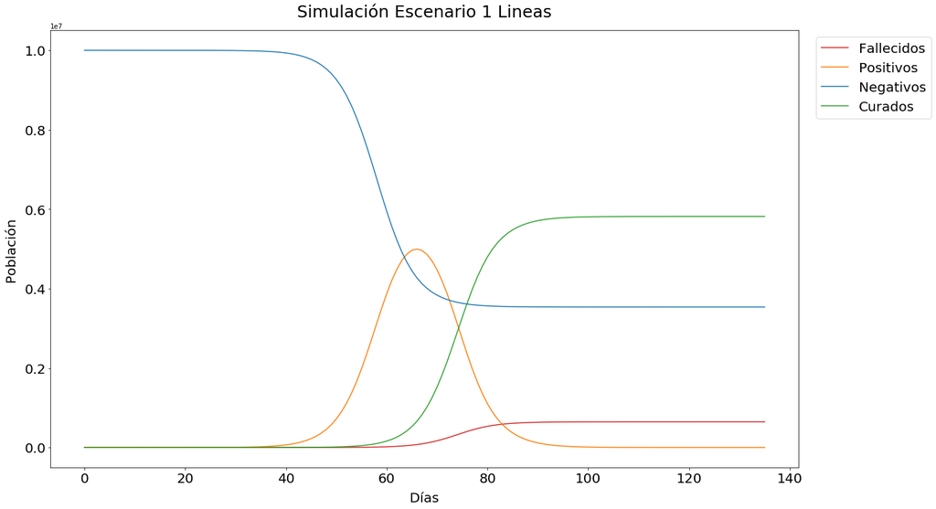

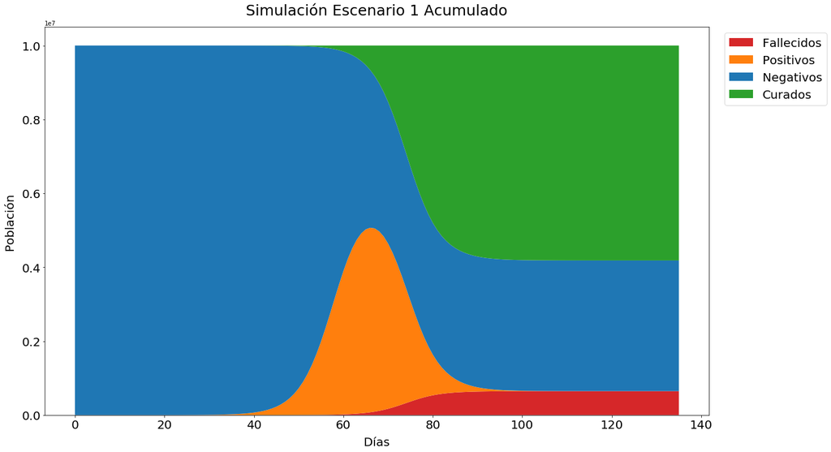

```python
#Número mínimo y máximo de personas con las que se tiene contacto en un día
num_relaciones_min = 1
num_relaciones_max = 12

#Probabilidad de contagio teniendo contacto con una persona contagiada
prob_contagio = 0.1

# % de población inmune al virus
prob_inmune = 0.33

#Genera los individuos de la población
poblacion = generaPoblacion()

#Relaciones entre las personas
relaciones = generaRelaciones()

#Inicializa contagios
poblacion = inicializaContagios(poblacion)

#Simulación
resultados = simulacion(poblacion, relaciones)

#Guardamos los resultados para su posterior estudio
guardarExcel(resultados, 'Resultados1.xlsx')

#Generamos los gráficos
generaGraficosLineas(resultados, 'SimulacionEscenario1_L.png', 'Simulación Escenario 1 (Sin medidas de prevención) Lineas')
generaGraficosAcumulado(resultados, 'SimulacionEscenario1_A.png', 'Simulación Escenario 1  (Sin medidas de prevención) Acumulado')
```

## Simulación Escenario 2 (Disminución de la libre circulación de personas)

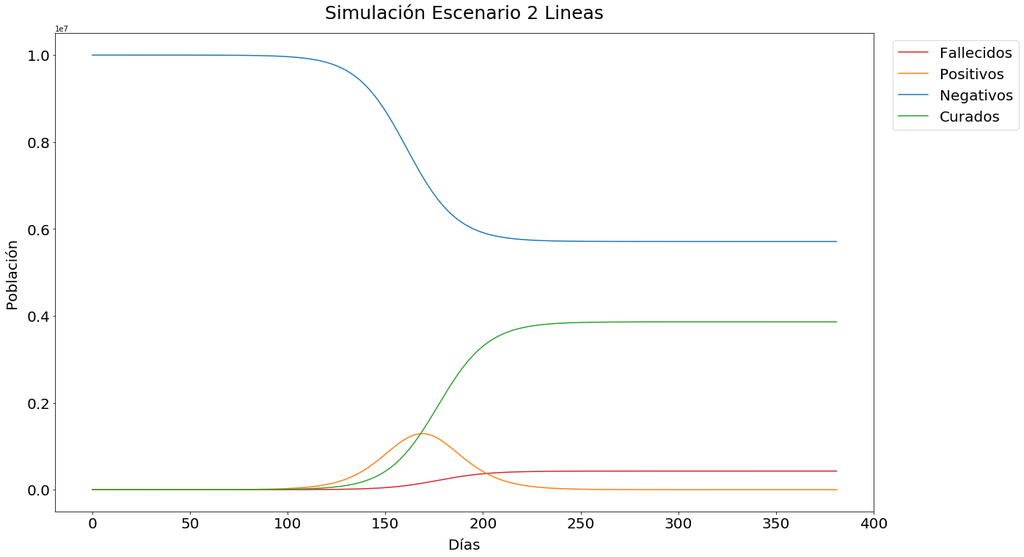

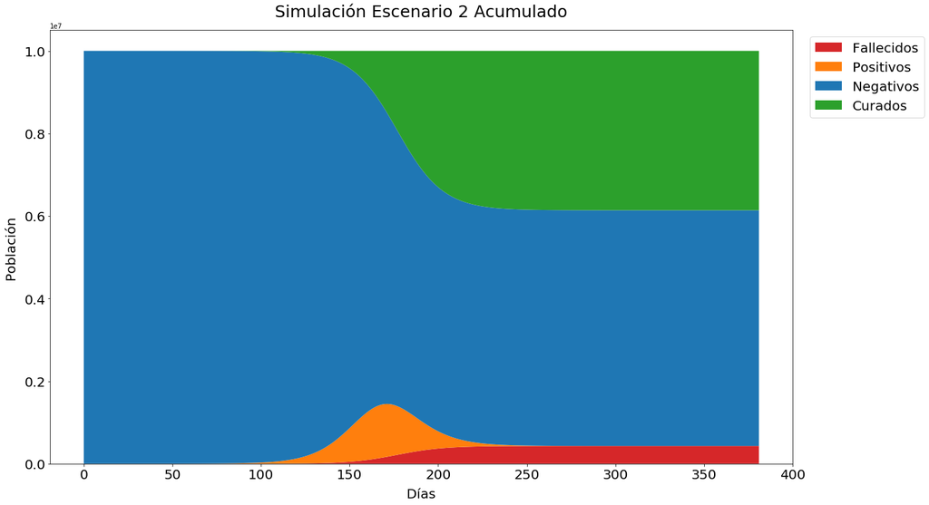

```python
#Número mínimo y máximo de personas con las que se tiene contacto en un día (reducido)
num_relaciones_min = 1
num_relaciones_max = 5

#Probabilidad de contagio teniendo contacto con una persona contagiada
prob_contagio = 0.1

# % de población inmune al virus
prob_inmune = 0.33

#Genera los individuos de la población
poblacion2 = generaPoblacion()

#Relaciones entre las personas, está vez menos relaciones
relaciones2 = generaRelaciones()

#Inicializa contagios
poblacion2 = inicializaContagios(poblacion2)

#Simulación
resultados2 = simulacion(poblacion2, relaciones2)

#Guardamos los resultados para su posterior estudio
guardarExcel(resultados2, 'Resultados2.xlsx')

#Generamos los gráficos
generaGraficosLineas(resultados2, 'SimulacionEscenario2_L.png', 'Simulación Escenario 2 (Disminución de la libre circulación de personas) Lineas')
generaGraficosAcumulado(resultados2, 'SimulacionEscenario2_A.png', 'Simulación Escenario 2 (Disminución de la libre circulación de personas) Acumulado')
```

## Simulación Escenario 3 (Uso de mascarilla)

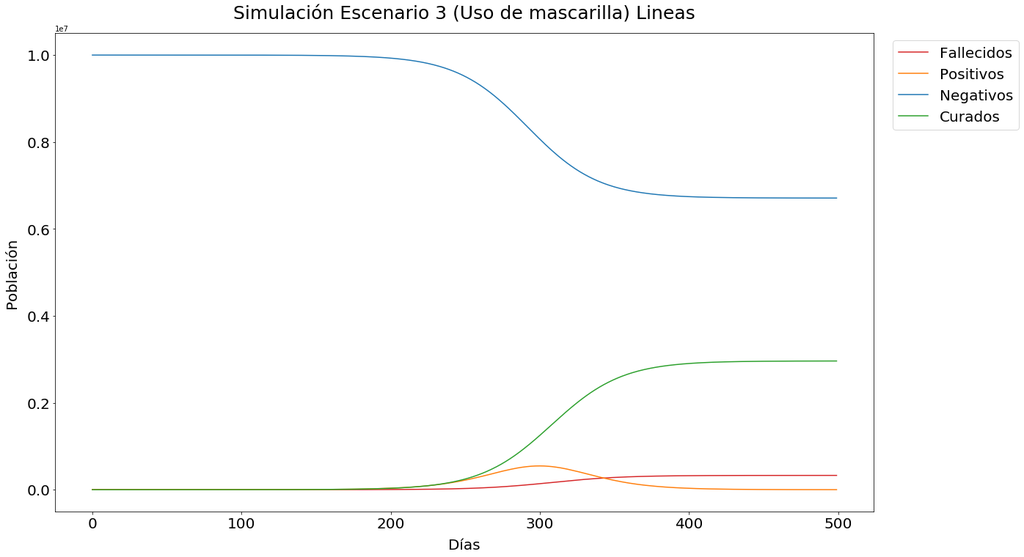

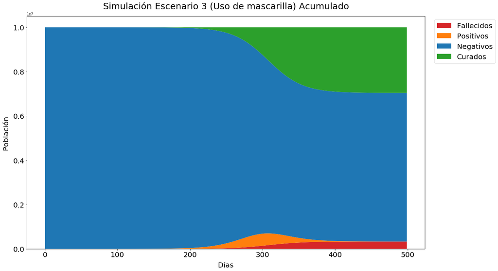

```python
#Número mínimo y máximo de personas con las que se tiene contacto en un día
num_relaciones_min = 1
num_relaciones_max = 12

#Probabilidad de contagio teniendo contacto con una persona contagiada (Usando mascarilla)
prob_contagio = 0.025

# % de población inmune al virus
prob_inmune = 0.33

#Genera los individuos de la población
poblacion3 = generaPoblacion()

#Relaciones entre las personas
relaciones3 = generaRelaciones()

#Inicializa contagios
poblacion3 = inicializaContagios(poblacion3)

#Simulación
resultados3 = simulacion(poblacion3, relaciones3)

#Guardamos los resultados para su posterior estudio
guardarExcel(resultados3, 'Resultados3.xlsx')

#Generamos los gráficos
generaGraficosLineas(resultados3, 'SimulacionEscenario3_L.png', 'Simulación Escenario 3 (Uso de mascarilla) Lineas')
generaGraficosAcumulado(resultados3, 'SimulacionEscenario3_A.png', 'Simulación Escenario 3 (Uso de mascarilla) Acumulado')
```

## Simulación Escenario 4 (Vacunación)

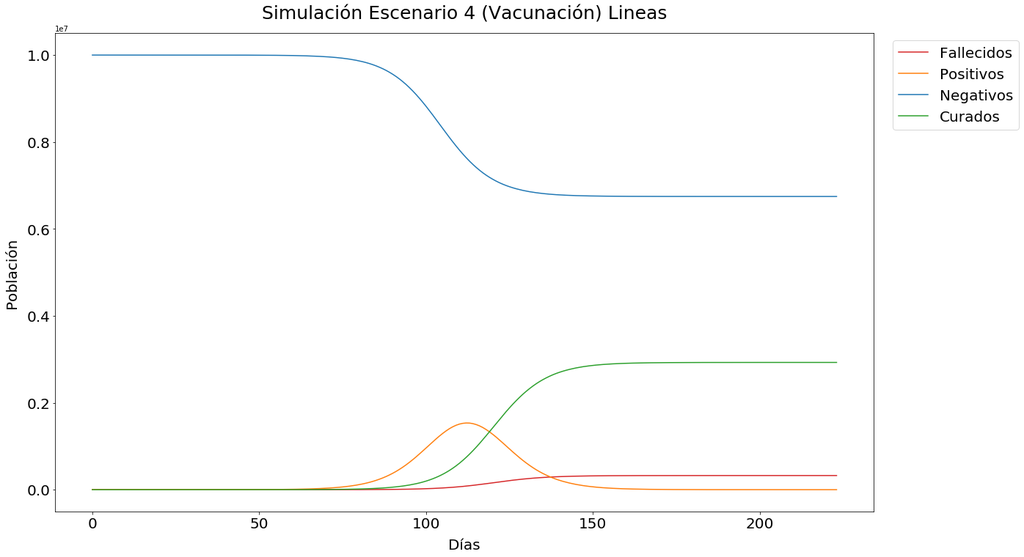

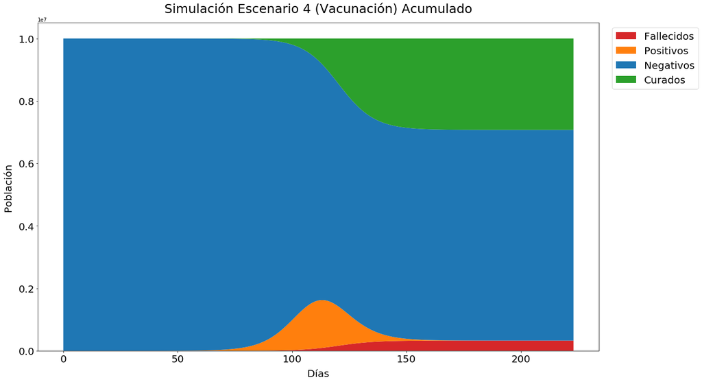

```python
#Número mínimo y máximo de personas con las que se tiene contacto en un día
num_relaciones_min = 1
num_relaciones_max = 12

#Probabilidad de contagio teniendo contacto con una persona contagiada
prob_contagio = 0.1

# % de población inmune al virus (Vacunación)
prob_inmune = 0.6

#Genera los individuos de la población
poblacion4 = generaPoblacion()

#Relaciones entre las personas
relaciones4 = generaRelaciones()

#Inicializa contagios
poblacion4 = inicializaContagios(poblacion4)

#Simulación
resultados4 = simulacion(poblacion4, relaciones4)

#Guardamos los resultados para su posterior estudio
guardarExcel(resultados4, 'Resultados4.xlsx')

#Generamos los gráficos
generaGraficosLineas(resultados4, 'SimulacionEscenario4_L.png', 'Simulación Escenario 4 (Vacunación) Lineas')
generaGraficosAcumulado(resultados4, 'SimulacionEscenario4_A.png', 'Simulación Escenario 4 (Vacunación) Acumulado')
```

## Comparativa de escenarios

```python
modelos = ['Escenario 1', 'Escenario 2', 'Escenario 3', 'Escenario 4']
tiempo = [max(resultados1[['dia'][0]]), max(resultados2[['dia'][0]]), max(resultados3[['dia'][0]]), max(resultados4[['dia'][0]])]
pico = [max(resultados1[['positivos'][0]]), max(resultados2[['positivos'][0]]), max(resultados3[['positivos'][0]]), max(resultados4[['positivos'][0]])]
contagios = [resultados1[resultados1['dia']==tiempo[0]]['curados'][tiempo[0]] + resultados1[resultados1['dia']==tiempo[0]]['fallecidos'][tiempo[0]], resultados2[resultados2['dia']==tiempo[1]]['curados'][tiempo[1]] + resultados2[resultados2['dia']==tiempo[1]]['fallecidos'][tiempo[1]], resultados3[resultados3['dia']==tiempo[2]]['curados'][tiempo[2]] + resultados3[resultados3['dia']==tiempo[2]]['fallecidos'][tiempo[2]], resultados4[resultados4['dia']==tiempo[3]]['curados'][tiempo[3]] + resultados4[resultados4['dia']==tiempo[3]]['fallecidos'][tiempo[3]]]
muertes = [resultados1[resultados1['dia']==tiempo[0]]['fallecidos'][tiempo[0]], resultados2[resultados2['dia']==tiempo[1]]['fallecidos'][tiempo[1]], resultados3[resultados3['dia']==tiempo[2]]['fallecidos'][tiempo[2]], resultados4[resultados4['dia']==tiempo[3]]['fallecidos'][tiempo[3]]]


data = {'Modelos':modelos, 'Tiempo':tiempo, 'Pico':pico, 'Contagios':contagios, 'Fallecimientos':muertes}

df_metrics = pd.DataFrame(data, columns = ['Modelos', 'Tiempo', 'Pico', 'Contagios', 'Fallecimientos'])

df_metrics
```

|  | Modelos | Tiempo | Pico | Contagios | Fallecimientos |
| --- | --- | --- | --- | --- | --- |
| 0 | Escenario 1 | 135 | 4995302 | 6463132 | 646215 |
| 1 | Escenario 2 | 381 | 1289126 | 4289623 | 428353 |
| 2 | Escenario 3 | 499 | 546853 | 3289615 | 328614 |
| 3 | Escenario 4 | 223 | 1534242 | 3253356 | 325373 |